# Risk Factor Analysis

## Outcome Variable

**Outcome Variable:** pers_wast

## Predictor Variables

**Intervention Variable:** hdlvry

**Adjustment Set:**

unadjusted

## Stratifying Variables

The analysis was stratified on these variable(s):

- agecat
- studyid
- country

## Data Summary

| agecat | studyid | country | hdlvry | pers_wast | n_cell | n |
| --- | --- | --- | --- | --- | --- | --- |
| 0-24 months | CMC-V-BCS-2002 | INDIA | 0 | 0 | 339 | 370 |
| 0-24 months | CMC-V-BCS-2002 | INDIA | 0 | 1 | 23 | 370 |
| 0-24 months | CMC-V-BCS-2002 | INDIA | 1 | 0 | 8 | 370 |
| 0-24 months | CMC-V-BCS-2002 | INDIA | 1 | 1 | 0 | 370 |
| 0-24 months | COHORTS | INDIA | 0 | 0 | 2249 | 3931 |
| 0-24 months | COHORTS | INDIA | 0 | 1 | 197 | 3931 |
| 0-24 months | COHORTS | INDIA | 1 | 0 | 1292 | 3931 |
| 0-24 months | COHORTS | INDIA | 1 | 1 | 193 | 3931 |
| 0-24 months | EE | PAKISTAN | 0 | 0 | 232 | 375 |
| 0-24 months | EE | PAKISTAN | 0 | 1 | 20 | 375 |
| 0-24 months | EE | PAKISTAN | 1 | 0 | 111 | 375 |
| 0-24 months | EE | PAKISTAN | 1 | 1 | 12 | 375 |
| 0-24 months | GMS-Nepal | NEPAL | 0 | 0 | 121 | 556 |
| 0-24 months | GMS-Nepal | NEPAL | 0 | 1 | 18 | 556 |
| 0-24 months | GMS-Nepal | NEPAL | 1 | 0 | 359 | 556 |
| 0-24 months | GMS-Nepal | NEPAL | 1 | 1 | 58 | 556 |
| 0-24 months | IRC | INDIA | 0 | 0 | 354 | 410 |
| 0-24 months | IRC | INDIA | 0 | 1 | 48 | 410 |
| 0-24 months | IRC | INDIA | 1 | 0 | 8 | 410 |
| 0-24 months | IRC | INDIA | 1 | 1 | 0 | 410 |
| 0-24 months | JiVitA-3 | BANGLADESH | 0 | 0 | 36 | 323 |
| 0-24 months | JiVitA-3 | BANGLADESH | 0 | 1 | 1 | 323 |
| 0-24 months | JiVitA-3 | BANGLADESH | 1 | 0 | 273 | 323 |
| 0-24 months | JiVitA-3 | BANGLADESH | 1 | 1 | 13 | 323 |
| 0-24 months | JiVitA-4 | BANGLADESH | 0 | 0 | 1077 | 4426 |
| 0-24 months | JiVitA-4 | BANGLADESH | 0 | 1 | 72 | 4426 |
| 0-24 months | JiVitA-4 | BANGLADESH | 1 | 0 | 2998 | 4426 |
| 0-24 months | JiVitA-4 | BANGLADESH | 1 | 1 | 279 | 4426 |
| 0-24 months | NIH-Crypto | BANGLADESH | 0 | 0 | 551 | 730 |
| 0-24 months | NIH-Crypto | BANGLADESH | 0 | 1 | 16 | 730 |

[output cut: 94 more lines]

The following strata were considered:

- agecat: 0-24 months, studyid: CMC-V-BCS-2002, country: INDIA
- agecat: 0-24 months, studyid: COHORTS, country: INDIA
- agecat: 0-24 months, studyid: EE, country: PAKISTAN
- agecat: 0-24 months, studyid: GMS-Nepal, country: NEPAL
- agecat: 0-24 months, studyid: IRC, country: INDIA
- agecat: 0-24 months, studyid: JiVitA-3, country: BANGLADESH
- agecat: 0-24 months, studyid: JiVitA-4, country: BANGLADESH
- agecat: 0-24 months, studyid: NIH-Crypto, country: BANGLADESH
- agecat: 0-24 months, studyid: PROVIDE, country: BANGLADESH
- agecat: 0-24 months, studyid: SAS-CompFeed, country: INDIA
- agecat: 0-24 months, studyid: SAS-FoodSuppl, country: INDIA
- agecat: 0-24 months, studyid: TanzaniaChild2, country: TANZANIA, UNITED REPUBLIC OF
- agecat: 0-6 months, studyid: CMC-V-BCS-2002, country: INDIA
- agecat: 0-6 months, studyid: EE, country: PAKISTAN
- agecat: 0-6 months, studyid: GMS-Nepal, country: NEPAL
- agecat: 0-6 months, studyid: IRC, country: INDIA
- agecat: 0-6 months, studyid: NIH-Crypto, country: BANGLADESH
- agecat: 0-6 months, studyid: PROVIDE, country: BANGLADESH
- agecat: 0-6 months, studyid: TanzaniaChild2, country: TANZANIA, UNITED REPUBLIC OF
- agecat: 6-24 months, studyid: CMC-V-BCS-2002, country: INDIA
- agecat: 6-24 months, studyid: COHORTS, country: INDIA
- agecat: 6-24 months, studyid: EE, country: PAKISTAN
- agecat: 6-24 months, studyid: GMS-Nepal, country: NEPAL
- agecat: 6-24 months, studyid: IRC, country: INDIA
- agecat: 6-24 months, studyid: JiVitA-3, country: BANGLADESH
- agecat: 6-24 months, studyid: JiVitA-4, country: BANGLADESH
- agecat: 6-24 months, studyid: NIH-Crypto, country: BANGLADESH
- agecat: 6-24 months, studyid: PROVIDE, country: BANGLADESH
- agecat: 6-24 months, studyid: SAS-CompFeed, country: INDIA
- agecat: 6-24 months, studyid: SAS-FoodSuppl, country: INDIA
- agecat: 6-24 months, studyid: TanzaniaChild2, country: TANZANIA, UNITED REPUBLIC OF

### Dropped Strata

Some strata were dropped due to rare outcomes:

- agecat: 0-24 months, studyid: CMC-V-BCS-2002, country: INDIA
- agecat: 0-24 months, studyid: IRC, country: INDIA
- agecat: 0-24 months, studyid: JiVitA-3, country: BANGLADESH
- agecat: 0-24 months, studyid: TanzaniaChild2, country: TANZANIA, UNITED REPUBLIC OF
- agecat: 0-6 months, studyid: CMC-V-BCS-2002, country: INDIA
- agecat: 0-6 months, studyid: IRC, country: INDIA
- agecat: 0-6 months, studyid: NIH-Crypto, country: BANGLADESH
- agecat: 0-6 months, studyid: PROVIDE, country: BANGLADESH
- agecat: 0-6 months, studyid: TanzaniaChild2, country: TANZANIA, UNITED REPUBLIC OF
- agecat: 6-24 months, studyid: CMC-V-BCS-2002, country: INDIA
- agecat: 6-24 months, studyid: IRC, country: INDIA
- agecat: 6-24 months, studyid: JiVitA-3, country: BANGLADESH
- agecat: 6-24 months, studyid: TanzaniaChild2, country: TANZANIA, UNITED REPUBLIC OF

## Methods Detail

We’re interested in the causal parameters $E[Y_a]$ for all values of $a \in \mathcal{A}$. These parameters represent the mean outcome if, possibly contrary to fact, we intervened to set all units to have $A=a$. Under the randomization and positivity assumptions, these are identified by the statistical parameters $\psi_a=E_W[E_{Y|A,W}(Y|A=a,W)]$. In addition, we’re interested in the mean of $Y$, $E[Y]$ under no intervention (the observed mean). We will estimate these parameters by using SuperLearner to fit the relevant likelihood factors – $E_{Y|A,W}(Y|A=a,W)$ and $p(A=a|W)$, and then updating our likelihood fit using a joint TMLE.

For unadjusted analyses ($W=\{\}$), initial likelihoods were estimated using Lrnr_glm to estimate the simple $E(Y|A)$ and Lrnr_mean to estimate $p(A)$. For adjusted analyses, a small library containing Lrnr_glmnet, Lrnr_xgboost, and Lrnr_mean was used.

Having estimated these parameters, we will then use the delta method to estimate relative risks and attributable risks relative to a prespecified baseline level of $A$.

# Results Detail

## Results Plots

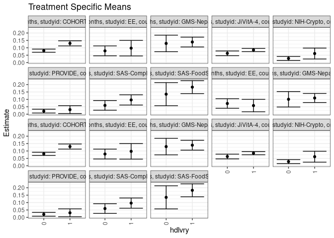

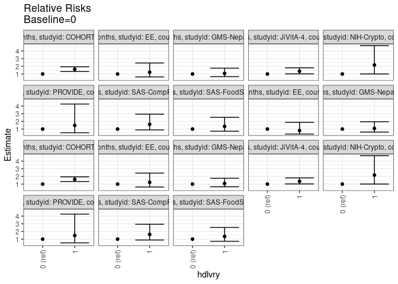

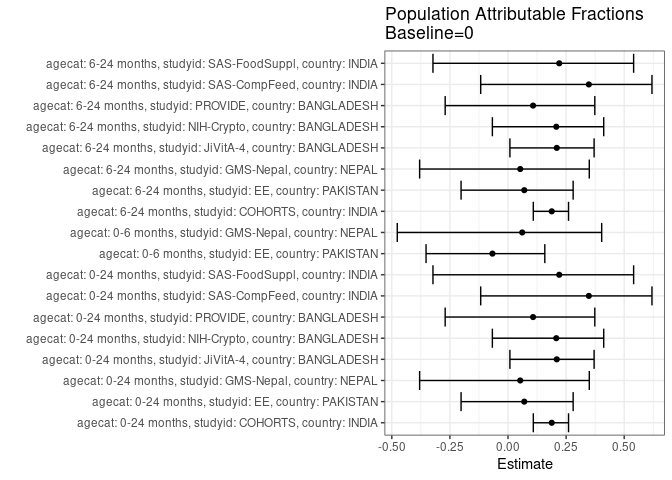

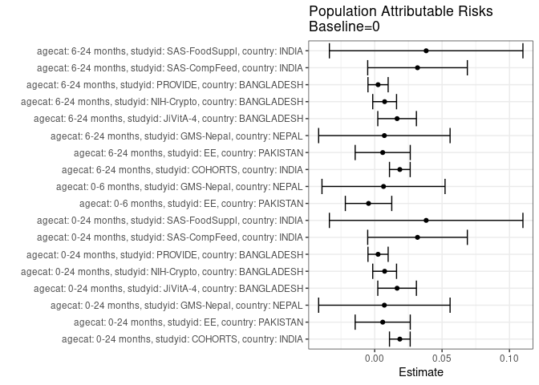

## Results Table

### Parameter: TSM

| agecat | studyid | country | intervention_level | baseline_level | estimate | ci_lower | ci_upper |
| --- | --- | --- | --- | --- | --- | --- | --- |
| 0-24 months | COHORTS | INDIA | 0 | NA | 0.0805397 | 0.0697540 | 0.0913253 |
| 0-24 months | COHORTS | INDIA | 1 | NA | 0.1299663 | 0.1128613 | 0.1470713 |
| 0-24 months | EE | PAKISTAN | 0 | NA | 0.0793651 | 0.0459466 | 0.1127835 |
| 0-24 months | EE | PAKISTAN | 1 | NA | 0.0975610 | 0.0450534 | 0.1500686 |
| 0-24 months | GMS-Nepal | NEPAL | 0 | NA | 0.1294964 | 0.0736306 | 0.1853622 |
| 0-24 months | GMS-Nepal | NEPAL | 1 | NA | 0.1390887 | 0.1058460 | 0.1723314 |
| 0-24 months | JiVitA-4 | BANGLADESH | 0 | NA | 0.0626632 | 0.0465229 | 0.0788035 |
| 0-24 months | JiVitA-4 | BANGLADESH | 1 | NA | 0.0851388 | 0.0742362 | 0.0960415 |
| 0-24 months | NIH-Crypto | BANGLADESH | 0 | NA | 0.0282187 | 0.0145789 | 0.0418585 |
| 0-24 months | NIH-Crypto | BANGLADESH | 1 | NA | 0.0613497 | 0.0244850 | 0.0982143 |
| 0-24 months | PROVIDE | BANGLADESH | 0 | NA | 0.0208768 | 0.0080633 | 0.0336904 |
| 0-24 months | PROVIDE | BANGLADESH | 1 | NA | 0.0308642 | 0.0042110 | 0.0575174 |
| 0-24 months | SAS-CompFeed | INDIA | 0 | NA | 0.0596026 | 0.0268592 | 0.0923461 |
| 0-24 months | SAS-CompFeed | INDIA | 1 | NA | 0.0963731 | 0.0619791 | 0.1307670 |
| 0-24 months | SAS-FoodSuppl | INDIA | 0 | NA | 0.1351351 | 0.0571395 | 0.2131308 |
| 0-24 months | SAS-FoodSuppl | INDIA | 1 | NA | 0.1827243 | 0.1390096 | 0.2264389 |
| 0-6 months | EE | PAKISTAN | 0 | NA | 0.0722892 | 0.0400799 | 0.1044984 |
| 0-6 months | EE | PAKISTAN | 1 | NA | 0.0583333 | 0.0163426 | 0.1003241 |
| 0-6 months | GMS-Nepal | NEPAL | 0 | NA | 0.1007752 | 0.0487788 | 0.1527716 |
| 0-6 months | GMS-Nepal | NEPAL | 1 | NA | 0.1094527 | 0.0789045 | 0.1400010 |
| 6-24 months | COHORTS | INDIA | 0 | NA | 0.0805397 | 0.0697540 | 0.0913253 |
| 6-24 months | COHORTS | INDIA | 1 | NA | 0.1299663 | 0.1128613 | 0.1470713 |
| 6-24 months | EE | PAKISTAN | 0 | NA | 0.0793651 | 0.0459466 | 0.1127835 |
| 6-24 months | EE | PAKISTAN | 1 | NA | 0.0975610 | 0.0450534 | 0.1500686 |
| 6-24 months | GMS-Nepal | NEPAL | 0 | NA | 0.1294964 | 0.0736306 | 0.1853622 |
| 6-24 months | GMS-Nepal | NEPAL | 1 | NA | 0.1390887 | 0.1058460 | 0.1723314 |
| 6-24 months | JiVitA-4 | BANGLADESH | 0 | NA | 0.0626632 | 0.0465229 | 0.0788035 |
| 6-24 months | JiVitA-4 | BANGLADESH | 1 | NA | 0.0851388 | 0.0742362 | 0.0960415 |
| 6-24 months | NIH-Crypto | BANGLADESH | 0 | NA | 0.0282187 | 0.0145789 | 0.0418585 |
| 6-24 months | NIH-Crypto | BANGLADESH | 1 | NA | 0.0613497 | 0.0244850 | 0.0982143 |
| 6-24 months | PROVIDE | BANGLADESH | 0 | NA | 0.0208768 | 0.0080633 | 0.0336904 |
| 6-24 months | PROVIDE | BANGLADESH | 1 | NA | 0.0308642 | 0.0042110 | 0.0575174 |
| 6-24 months | SAS-CompFeed | INDIA | 0 | NA | 0.0596026 | 0.0268592 | 0.0923461 |
| 6-24 months | SAS-CompFeed | INDIA | 1 | NA | 0.0963731 | 0.0619791 | 0.1307670 |
| 6-24 months | SAS-FoodSuppl | INDIA | 0 | NA | 0.1351351 | 0.0571395 | 0.2131308 |
| 6-24 months | SAS-FoodSuppl | INDIA | 1 | NA | 0.1827243 | 0.1390096 | 0.2264389 |

### Parameter: E(Y)

| agecat | studyid | country | intervention_level | baseline_level | estimate | ci_lower | ci_upper |
| --- | --- | --- | --- | --- | --- | --- | --- |
| 0-24 months | COHORTS | INDIA | NA | NA | 0.0992114 | 0.0898650 | 0.1085578 |
| 0-24 months | EE | PAKISTAN | NA | NA | 0.0853333 | 0.0570192 | 0.1136475 |
| 0-24 months | GMS-Nepal | NEPAL | NA | NA | 0.1366906 | 0.1081112 | 0.1652701 |
| 0-24 months | JiVitA-4 | BANGLADESH | NA | NA | 0.0793041 | 0.0701363 | 0.0884719 |
| 0-24 months | NIH-Crypto | BANGLADESH | NA | NA | 0.0356164 | 0.0221630 | 0.0490699 |
| 0-24 months | PROVIDE | BANGLADESH | NA | NA | 0.0234009 | 0.0116889 | 0.0351130 |
| 0-24 months | SAS-CompFeed | INDIA | NA | NA | 0.0913978 | 0.0593363 | 0.1234594 |
| 0-24 months | SAS-FoodSuppl | INDIA | NA | NA | 0.1733333 | 0.1349698 | 0.2116969 |
| 0-6 months | EE | PAKISTAN | NA | NA | 0.0677507 | 0.0420735 | 0.0934278 |
| 0-6 months | GMS-Nepal | NEPAL | NA | NA | 0.1073446 | 0.0809909 | 0.1336984 |
| 6-24 months | COHORTS | INDIA | NA | NA | 0.0992114 | 0.0898650 | 0.1085578 |
| 6-24 months | EE | PAKISTAN | NA | NA | 0.0853333 | 0.0570192 | 0.1136475 |
| 6-24 months | GMS-Nepal | NEPAL | NA | NA | 0.1366906 | 0.1081112 | 0.1652701 |
| 6-24 months | JiVitA-4 | BANGLADESH | NA | NA | 0.0793041 | 0.0701363 | 0.0884719 |
| 6-24 months | NIH-Crypto | BANGLADESH | NA | NA | 0.0356164 | 0.0221630 | 0.0490699 |
| 6-24 months | PROVIDE | BANGLADESH | NA | NA | 0.0234009 | 0.0116889 | 0.0351130 |
| 6-24 months | SAS-CompFeed | INDIA | NA | NA | 0.0913978 | 0.0593363 | 0.1234594 |
| 6-24 months | SAS-FoodSuppl | INDIA | NA | NA | 0.1733333 | 0.1349698 | 0.2116969 |

### Parameter: RR

| agecat | studyid | country | intervention_level | baseline_level | estimate | ci_lower | ci_upper |
| --- | --- | --- | --- | --- | --- | --- | --- |
| 0-24 months | COHORTS | INDIA | 0 | 0 | 1.0000000 | 1.0000000 | 1.000000 |
| 0-24 months | COHORTS | INDIA | 1 | 0 | 1.6136936 | 1.3374458 | 1.947000 |
| 0-24 months | EE | PAKISTAN | 0 | 0 | 1.0000000 | 1.0000000 | 1.000000 |
| 0-24 months | EE | PAKISTAN | 1 | 0 | 1.2292683 | 0.6206867 | 2.434563 |
| 0-24 months | GMS-Nepal | NEPAL | 0 | 0 | 1.0000000 | 1.0000000 | 1.000000 |
| 0-24 months | GMS-Nepal | NEPAL | 1 | 0 | 1.0740741 | 0.6559111 | 1.758828 |
| 0-24 months | JiVitA-4 | BANGLADESH | 0 | 0 | 1.0000000 | 1.0000000 | 1.000000 |
| 0-24 months | JiVitA-4 | BANGLADESH | 1 | 0 | 1.3586741 | 1.0210158 | 1.807999 |
| 0-24 months | NIH-Crypto | BANGLADESH | 0 | 0 | 1.0000000 | 1.0000000 | 1.000000 |
| 0-24 months | NIH-Crypto | BANGLADESH | 1 | 0 | 2.1740798 | 1.0054462 | 4.701020 |
| 0-24 months | PROVIDE | BANGLADESH | 0 | 0 | 1.0000000 | 1.0000000 | 1.000000 |
| 0-24 months | PROVIDE | BANGLADESH | 1 | 0 | 1.4783951 | 0.5124750 | 4.264895 |
| 0-24 months | SAS-CompFeed | INDIA | 0 | 0 | 1.0000000 | 1.0000000 | 1.000000 |
| 0-24 months | SAS-CompFeed | INDIA | 1 | 0 | 1.6169257 | 0.8882404 | 2.943402 |
| 0-24 months | SAS-FoodSuppl | INDIA | 0 | 0 | 1.0000000 | 1.0000000 | 1.000000 |
| 0-24 months | SAS-FoodSuppl | INDIA | 1 | 0 | 1.3521595 | 0.7239137 | 2.525626 |
| 0-6 months | EE | PAKISTAN | 0 | 0 | 1.0000000 | 1.0000000 | 1.000000 |
| 0-6 months | EE | PAKISTAN | 1 | 0 | 0.8069444 | 0.3460819 | 1.881518 |
| 0-6 months | GMS-Nepal | NEPAL | 0 | 0 | 1.0000000 | 1.0000000 | 1.000000 |
| 0-6 months | GMS-Nepal | NEPAL | 1 | 0 | 1.0861079 | 0.6041012 | 1.952703 |
| 6-24 months | COHORTS | INDIA | 0 | 0 | 1.0000000 | 1.0000000 | 1.000000 |
| 6-24 months | COHORTS | INDIA | 1 | 0 | 1.6136936 | 1.3374458 | 1.947000 |
| 6-24 months | EE | PAKISTAN | 0 | 0 | 1.0000000 | 1.0000000 | 1.000000 |
| 6-24 months | EE | PAKISTAN | 1 | 0 | 1.2292683 | 0.6206867 | 2.434563 |
| 6-24 months | GMS-Nepal | NEPAL | 0 | 0 | 1.0000000 | 1.0000000 | 1.000000 |
| 6-24 months | GMS-Nepal | NEPAL | 1 | 0 | 1.0740741 | 0.6559111 | 1.758828 |
| 6-24 months | JiVitA-4 | BANGLADESH | 0 | 0 | 1.0000000 | 1.0000000 | 1.000000 |
| 6-24 months | JiVitA-4 | BANGLADESH | 1 | 0 | 1.3586741 | 1.0210158 | 1.807999 |
| 6-24 months | NIH-Crypto | BANGLADESH | 0 | 0 | 1.0000000 | 1.0000000 | 1.000000 |
| 6-24 months | NIH-Crypto | BANGLADESH | 1 | 0 | 2.1740798 | 1.0054462 | 4.701020 |
| 6-24 months | PROVIDE | BANGLADESH | 0 | 0 | 1.0000000 | 1.0000000 | 1.000000 |
| 6-24 months | PROVIDE | BANGLADESH | 1 | 0 | 1.4783951 | 0.5124750 | 4.264895 |
| 6-24 months | SAS-CompFeed | INDIA | 0 | 0 | 1.0000000 | 1.0000000 | 1.000000 |
| 6-24 months | SAS-CompFeed | INDIA | 1 | 0 | 1.6169257 | 0.8882404 | 2.943402 |
| 6-24 months | SAS-FoodSuppl | INDIA | 0 | 0 | 1.0000000 | 1.0000000 | 1.000000 |
| 6-24 months | SAS-FoodSuppl | INDIA | 1 | 0 | 1.3521595 | 0.7239137 | 2.525626 |

### Parameter: PAR

| agecat | studyid | country | intervention_level | baseline_level | estimate | ci_lower | ci_upper |
| --- | --- | --- | --- | --- | --- | --- | --- |
| 0-24 months | COHORTS | INDIA | 0 | NA | 0.0186717 | 0.0109961 | 0.0263474 |
| 0-24 months | EE | PAKISTAN | 0 | NA | 0.0059683 | -0.0144649 | 0.0264014 |
| 0-24 months | GMS-Nepal | NEPAL | 0 | NA | 0.0071942 | -0.0415631 | 0.0559516 |
| 0-24 months | JiVitA-4 | BANGLADESH | 0 | NA | 0.0166409 | 0.0023182 | 0.0309636 |
| 0-24 months | NIH-Crypto | BANGLADESH | 0 | NA | 0.0073977 | -0.0014360 | 0.0162315 |
| 0-24 months | PROVIDE | BANGLADESH | 0 | NA | 0.0025241 | -0.0049575 | 0.0100057 |
| 0-24 months | SAS-CompFeed | INDIA | 0 | NA | 0.0317952 | -0.0051651 | 0.0687555 |
| 0-24 months | SAS-FoodSuppl | INDIA | 0 | NA | 0.0381982 | -0.0335945 | 0.1099909 |
| 0-6 months | EE | PAKISTAN | 0 | NA | -0.0045385 | -0.0217616 | 0.0126846 |
| 0-6 months | GMS-Nepal | NEPAL | 0 | NA | 0.0065694 | -0.0390871 | 0.0522260 |
| 6-24 months | COHORTS | INDIA | 0 | NA | 0.0186717 | 0.0109961 | 0.0263474 |
| 6-24 months | EE | PAKISTAN | 0 | NA | 0.0059683 | -0.0144649 | 0.0264014 |
| 6-24 months | GMS-Nepal | NEPAL | 0 | NA | 0.0071942 | -0.0415631 | 0.0559516 |
| 6-24 months | JiVitA-4 | BANGLADESH | 0 | NA | 0.0166409 | 0.0023182 | 0.0309636 |
| 6-24 months | NIH-Crypto | BANGLADESH | 0 | NA | 0.0073977 | -0.0014360 | 0.0162315 |
| 6-24 months | PROVIDE | BANGLADESH | 0 | NA | 0.0025241 | -0.0049575 | 0.0100057 |
| 6-24 months | SAS-CompFeed | INDIA | 0 | NA | 0.0317952 | -0.0051651 | 0.0687555 |
| 6-24 months | SAS-FoodSuppl | INDIA | 0 | NA | 0.0381982 | -0.0335945 | 0.1099909 |

### Parameter: PAF

| agecat | studyid | country | intervention_level | baseline_level | estimate | ci_lower | ci_upper |
| --- | --- | --- | --- | --- | --- | --- | --- |
| 0-24 months | COHORTS | INDIA | 0 | NA | 0.1882016 | 0.1088814 | 0.2604613 |
| 0-24 months | EE | PAKISTAN | 0 | NA | 0.0699405 | -0.2019552 | 0.2803303 |
| 0-24 months | GMS-Nepal | NEPAL | 0 | NA | 0.0526316 | -0.3803296 | 0.3497880 |
| 0-24 months | JiVitA-4 | BANGLADESH | 0 | NA | 0.2098369 | 0.0082102 | 0.3704737 |
| 0-24 months | NIH-Crypto | BANGLADESH | 0 | NA | 0.2077059 | -0.0672795 | 0.4118411 |
| 0-24 months | PROVIDE | BANGLADESH | 0 | NA | 0.1078636 | -0.2703716 | 0.3734846 |
| 0-24 months | SAS-CompFeed | INDIA | 0 | NA | 0.3478769 | -0.1175046 | 0.6194516 |
| 0-24 months | SAS-FoodSuppl | INDIA | 0 | NA | 0.2203742 | -0.3229179 | 0.5405487 |
| 0-6 months | EE | PAKISTAN | 0 | NA | -0.0669880 | -0.3526787 | 0.1583639 |
| 0-6 months | GMS-Nepal | NEPAL | 0 | NA | 0.0611995 | -0.4765116 | 0.4030888 |
| 6-24 months | COHORTS | INDIA | 0 | NA | 0.1882016 | 0.1088814 | 0.2604613 |
| 6-24 months | EE | PAKISTAN | 0 | NA | 0.0699405 | -0.2019552 | 0.2803303 |
| 6-24 months | GMS-Nepal | NEPAL | 0 | NA | 0.0526316 | -0.3803296 | 0.3497880 |
| 6-24 months | JiVitA-4 | BANGLADESH | 0 | NA | 0.2098369 | 0.0082102 | 0.3704737 |
| 6-24 months | NIH-Crypto | BANGLADESH | 0 | NA | 0.2077059 | -0.0672795 | 0.4118411 |
| 6-24 months | PROVIDE | BANGLADESH | 0 | NA | 0.1078636 | -0.2703716 | 0.3734846 |
| 6-24 months | SAS-CompFeed | INDIA | 0 | NA | 0.3478769 | -0.1175046 | 0.6194516 |
| 6-24 months | SAS-FoodSuppl | INDIA | 0 | NA | 0.2203742 | -0.3229179 | 0.5405487 |